# Lecture 2: Conditional Probability, Independence

Jamie Haddock

## Recap: Probabilistic Models

A probabilistic model is a sample space $\Omega$ and a probability law $P$. Sample spaces come in two flavors: **discrete** ($\Omega$ finite or countably infinite – die rolls, coin flips, number of arrivals) and **continuous** ($\Omega$ an uncountable continuum, typically an interval or region of $\mathbb{R}^n$ – a waiting time, a location). We’ll build the discrete theory first and turn to continuous models in a few weeks.

**Exercise**

For each experiment, is the natural sample space discrete or continuous? (a) number of heads in 10 coin flips (b) how long you wait for the bus (c) which of 6 faces a die lands on (d) the row index sampled by randomized Kaczmarz at a given iteration (e) proportion of salt to pepper sprinkled into my mashed potatoes

**Answer:**

1. discrete (b) continuous (c) discrete (d) discrete (it’s one of $1,\ldots,m$) (e) continuous.

# Conditional Probability

So far, every probability we’ve computed has used the *full* sample space $\Omega$. But we very often learn **partial information** about an experiment before we need to reason further about it – a medical test comes back positive, a die roll is reported even, a randomized algorithm’s first random choice has already been made. Conditional probability updates our probabilities in light of exactly this kind of partial information.

## Building the definition: a dice example

Roll a fair die, $\Omega=\{1,\ldots,6\}$. Suppose we’re told the roll came out **even** – event $B=\{2,4,6\}$. Given this, what’s the probability the roll was exactly $2$? Once we know $B$ occurred, only the three outcomes in $B$ remain possible, and they’re still equally likely *relative to each other*. So
$$P(\{2\}\mid B) = \frac13.$$

Let’s rewrite $\frac13$ in terms of the *original* probabilities:
$$\frac13 = \frac{|{2}|}{|B|} = \frac{P(\{2\}\cap B)}{P(B)}$$
(using $\{2\}\subseteq B$).

**Definition: Conditional probability**

For events $A,B$ with $P(B)>0$, the **conditional probability of $A$ given $B$** is
$$P(A\mid B) = \frac{P(A\cap B)}{P(B)}.$$

## Activity: the conditional probability law is a probability law

Fix an event $B$ with $P(B)>0$. Break into five groups and prove – using only $P(A\mid B)=P(A\cap B)/P(B)$ and what we already know about $P$ – that $P(A|B)$ satisfies:

1. **Nonnegativity:** $P(A|B) \geq 0$.
2. **(Finite) additivity:** $A_1,A_2$ disjoint $\Rightarrow P(A_1\cup A_2|B)=P(A_1|B)+P(A_2|B)$.
3. **Normalization:** $P(\Omega|B)=1$.
4. **Monotonicity:** $A_1\subseteq A_2 \Rightarrow P(A_1|B)\le P(A_2|B)$.
5. **Inclusion-Exclusion:** $P(A_1\cup A_2|B)=P(A_1|B)+P(A_2|B)-P(A_1\cap A_2|B)$.

**Exercise**

Let’s write the five proofs!

**Note**

**Takeaway:** any fact that follows from just the three axioms holds for *every* probability law – so it automatically holds for any conditional probability law too.

**Note**

$P(\cdot\mid B)$ can also be viewed as an ordinary probability law living on the *smaller* sample space $B$ itself: restrict attention to outcomes in $B$ and rescale so they sum to $1$. When $\Omega$ is finite with every outcome **equally likely**, this rescaling is just counting:
$$P(A\mid B) = \frac{|A\cap B|}{|B|}.$$

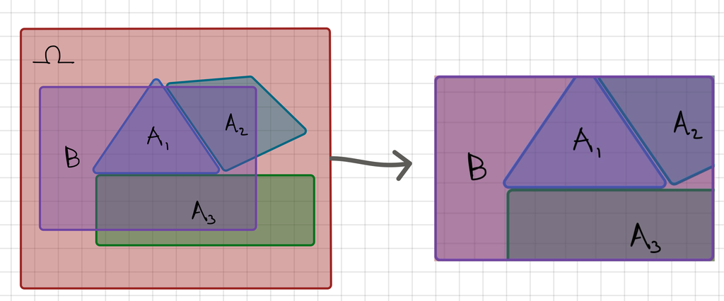

## Two dice: max and min

Roll two dice with outcomes $X,Y$. Let $B=\{\min(X,Y)=2\}$, and for $m=1,\ldots,6$ let $A_m=\{\max(X,Y)=m\}$. Since $\Omega$ is uniform (36 equally likely pairs), we can compute every $P(A_m\mid B)$ by counting.

```python
outcomes = [(x, y) for x in range(1, 7) for y in range(1, 7)]
B = [(x, y) for (x, y) in outcomes if min(x, y) == 2]
```

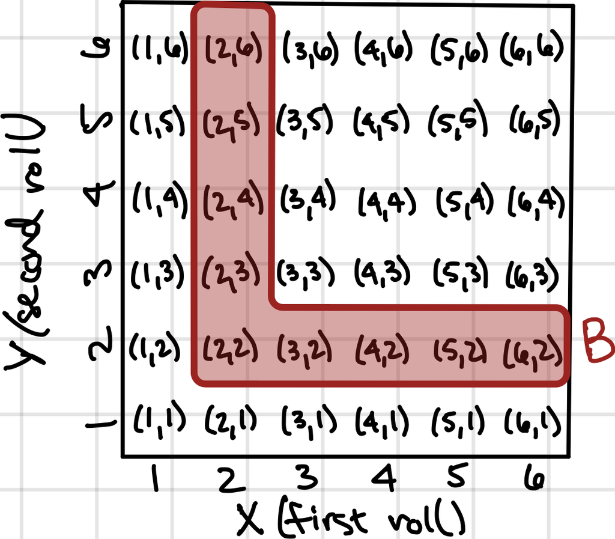

```python
for m in range(1, 7):
    A_m = [(x, y) for (x, y) in outcomes if max(x, y) == m]
    inter = set(A_m) & set(B)
    p_cond = len(inter) / len(B)
    print(f"P(max = {m} | min = 2) = {len(inter)}/{len(B)} = {p_cond:.4f}")
```

```
P(max = 1 | min = 2) = 0/9 = 0.0000
P(max = 2 | min = 2) = 1/9 = 0.1111
P(max = 3 | min = 2) = 2/9 = 0.2222
P(max = 4 | min = 2) = 2/9 = 0.2222
P(max = 5 | min = 2) = 2/9 = 0.2222
P(max = 6 | min = 2) = 2/9 = 0.2222
```

Notice these six numbers sum to $1$ – they must, since $A_1,\ldots,A_6$ partition $\Omega$ (this is due to the law of total probability which we’ll see later today).

## Randomized Kaczmarz: with vs. without replacement

Standard randomized Kaczmarz draws a fresh row index $I_k\sim p$ at *every* iteration, without consideration for past draws – **sampling with replacement**. A natural alternative cycles through a random reordering of the rows each epoch, never repeating a row until every row has been used – **sampling without replacement**. Conditional probability lets us see these are different.

$P_{\text{with replacement}}(I_2 = 7 | I_1 = 7) = p_7$

$P_{\text{without replacement}}(I_2 = 7 | I_1 = 7) = 0$

With replacement, conditioning on $I_1$ doesn’t move the probability for $I_2$ at all. Without replacement, it moves it all the way to zero.

## A COVID test: false positives and false negatives

Let $D$ = “has the disease” and $+$ = “tests positive.” Suppose $P(D)=0.02$ (2% prevalence), the test’s **sensitivity** is $P(+\mid D)=0.95$, and its **specificity** is $P(-\mid D^c)=0.98$ (so $P(+\mid D^c)=0.02$ and $P(-\mid D)=0.05$).

What is the probability that a patient does not have the disease and tests positive? What is the probability that a patient has the disease and tests negative?

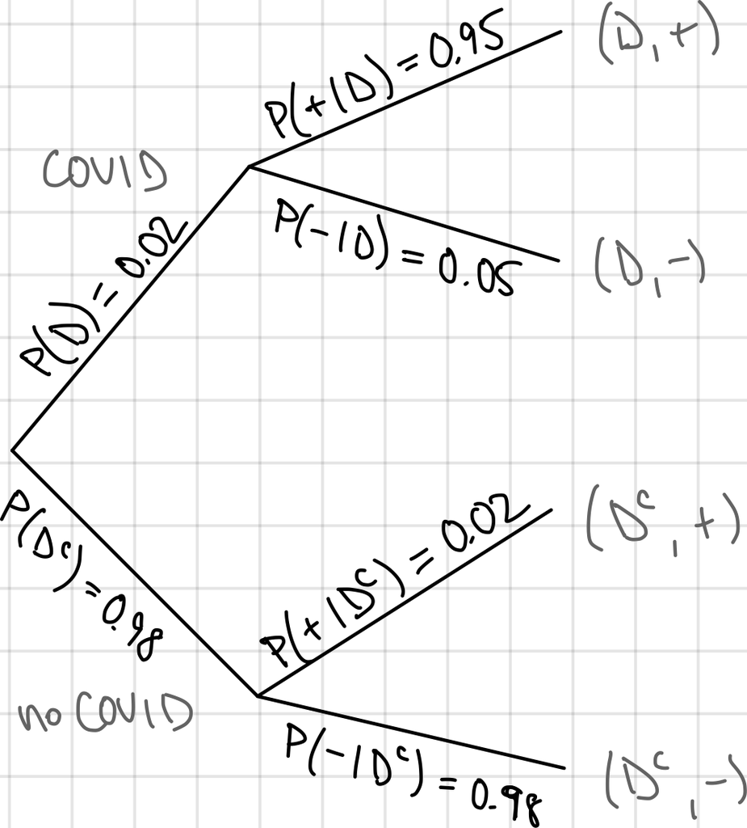

$P(D^c \cap +) = P(D^c)P(+ | D^c) = 0.98*0.02 = 0.0196$

$P(D \cap -) = P(D)P(- | D) = 0.02*0.05 = 0.001$

We’ll compute $P(+)$ (total probability theorem) and then $P(D\mid +)$ (Bayes’ rule) in a few minutes – keep this tree in mind.

## Multiplication rule

**Theorem: Multiplication Rule**

For events $A_1,\ldots,A_n$ with $P(A_1\cap\cdots\cap A_{n-1})>0$:
$$P(A_1\cap A_2\cap\cdots\cap A_n) = P(A_1)\,P(A_2\mid A_1)\,P(A_3\mid A_1\cap A_2)\cdots P(A_n\mid A_1\cap\cdots\cap A_{n-1}).$$

**Exercise**

Prove the multiplication rule. *(Hint: write each factor using the definition of conditional probability, and look for a telescoping product.)*

**Answer:**

Write out each conditional-probability factor by definition:
$$P(A_1)\cdot\frac{P(A_1\cap A_2)}{P(A_1)}\cdot\frac{P(A_1\cap A_2\cap A_3)}{P(A_1\cap A_2)}\cdots\frac{P(A_1\cap\cdots\cap A_n)}{P(A_1\cap\cdots\cap A_{n-1})}.$$
The product telescopes, leaving only $P(A_1\cap\cdots\cap A_n)$, the numerator of the last factor. $\blacksquare$

# The Law of Total Probability (LoTP)

**Theorem: Law of Total Probability**

If $B_1,\ldots,B_n$ **partition** $\Omega$ (pairwise disjoint, union $=\Omega$, each $P(B_i)>0$), then for any event $A$:
$$P(A) = \sum_{i=1}^n P(B_i)\,P(A\mid B_i).$$

**Proof:**

$A = \bigcup_i (A\cap B_i)$, and these pieces are pairwise disjoint since the $B_i$ are. By additivity, $P(A) = \sum_i P(A\cap B_i)$. Rewrite each term using the definition of conditional probability, $P(A\cap B_i) = P(B_i)P(A\mid B_i)$. $\blacksquare$

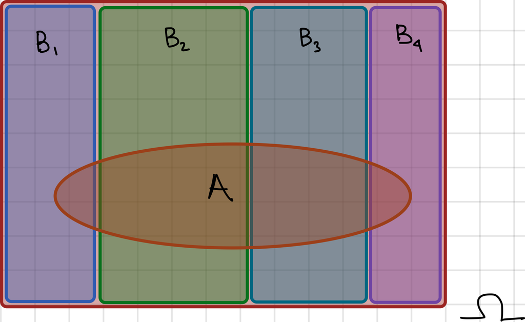

# Bayes’ Rule

**Theorem: Bayes’ Rule**

For events $A,B$ with $P(A),P(B)>0$:
$$P(B\mid A) = \frac{P(A\mid B)\,P(B)}{P(A)} = \frac{P(A\mid B)\,P(B)}{\sum_i P(A\mid B_i)\,P(B_i)},$$
where the denominator is expanded via the total probability theorem over any partition $B_1,\ldots,B_n$ containing $B$.

**Proof:**

$P(A\cap B) = P(A\mid B)P(B)$ and also $= P(B\mid A)P(A)$, by the multiplication rule applied in each order. Setting these equal and solving for $P(B\mid A)$ gives the result; expand $P(A)$ via the total probability theorem for the second form. $\blacksquare$

**Back to the COVID test.** We have $P(D)=0.02$, $P(+\mid D)=0.95$, $P(+\mid D^c)=0.02$. Total probability gives $P(+)$; Bayes’ rule then tells us what we actually want to know after seeing a result.

```python
p_D, p_pos_given_D, p_pos_given_Dc = 0.02, 0.95, 0.02
p_Dc = 1 - p_D
p_pos = p_D * p_pos_given_D + p_Dc * p_pos_given_Dc

p_D_given_pos = p_D * p_pos_given_D / p_pos
print(f"P(+) = {p_pos:.4f}   (total probability theorem)")
print(f"P(D | +) = {p_D_given_pos:.4f}   (Bayes' rule)")

p_neg = 1 - p_pos
p_D_given_neg = p_D * (1 - p_pos_given_D) / p_neg
print(f"P(D | -) = {p_D_given_neg:.5f}")
```

```
P(+) = 0.0386   (total probability theorem)
P(D | +) = 0.4922   (Bayes' rule)
P(D | -) = 0.00104
```

Even with a 95%-sensitive, 98%-specific test, a positive result only makes infection approximately 50% likely – because the disease is rare, false positives from the huge healthy population outnumber true positives.

# The Monty Hall Problem

Three doors; a car behind one, goats behind the other two. You pick a door and win whatever is behind the door. The game show host Monty Hall – who knows where the car is – opens a *different* door, always revealing a goat, then offers you the chance to switch. Should you?

[figure not shown]

Suppose you choose door 1 and then Monty opens door 2. What should you do?

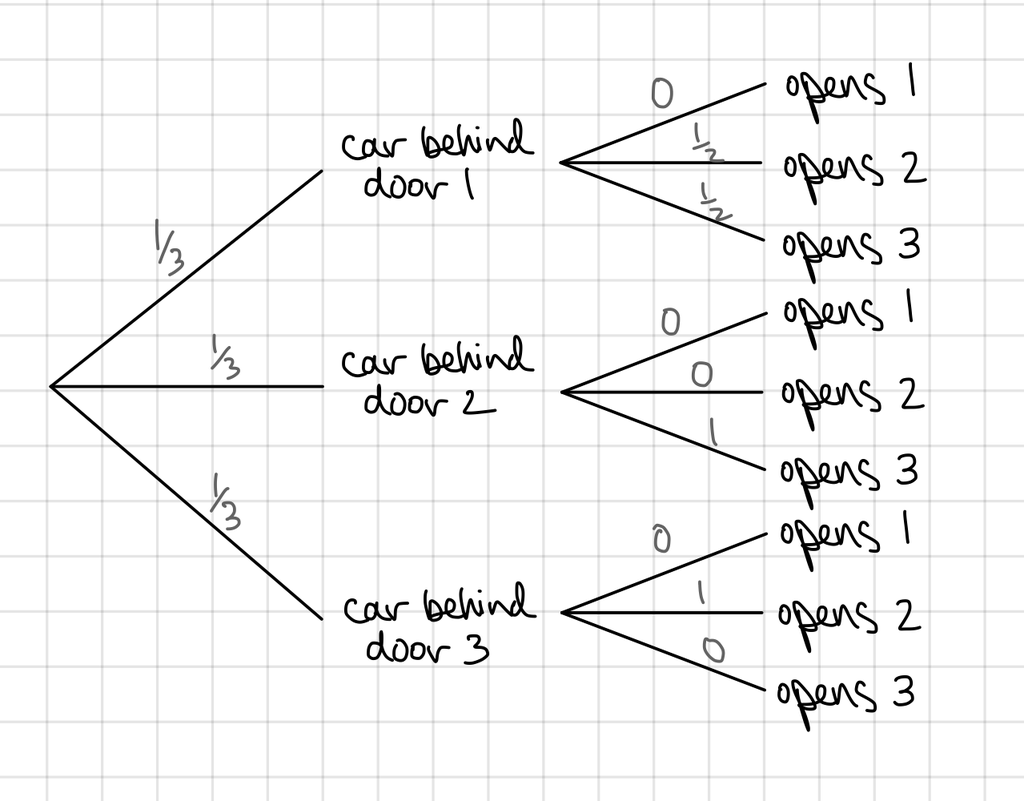

$P(car 1 | opens 2) = \frac{P(car 1)P(opens 2| car 1)}{P(opens 2)} = \frac{1/3*1/2}{1/3*1/2 + 1/3*1} = 1/3$

$P(car 2 | opens 2) = \frac{P(car 2)P(opens 2| car 2)}{P(opens 2)} = \frac{1/3*0}{1/3*1/2 + 1/3*1} = 0$

$P(car 3 | opens 2) = \frac{P(car 3)P(opens 2| car 3)}{P(opens 2)} = \frac{1/3*1}{1/3*1/2 + 1/3*1} = 2/3$

The best strategy is to switch!

# Independent Events

**Definition: Independent events**

Events $A,B$ are **independent** if
$$P(A\cap B) = P(A)\,P(B).$$
Equivalently, whenever $P(B)>0$: $P(A\mid B) = P(A)$ (divide both sides by $P(B)$) – and symmetrically $P(B\mid A)=P(B)$ when $P(A)>0$. These are all the same statement.

**Intuition:** $B$ is independent of $A$ if learning that $B$ occurred gives us *no new information* about whether $A$ occurred – our probability for $A$ doesn’t move.

## Randomized Kaczmarz, revisited

Now we can say precisely what was hinted at earlier: sampling rows **with replacement** makes consecutive draws *independent* – $P(I_2=i\mid I_1=j)=p_i=P(I_2=i)$ for every $j$. Sampling **without replacement** makes them *dependent*: $P(I_2=i\mid I_1=i)=0\neq p_i$.

## Two dice: independent or not?

**Exercise**

Roll two fair dice $X,Y$. Let $A=\{X+Y=7\}$, $B=\{X=4\}$. Are $A,B$ independent?

**Answer:**

$P(A)=6/36=\tfrac16$, $P(B)=\tfrac16$. $A\cap B=\{(4,3)\}$ (the only way to get $X=4$ *and* sum $7$), so $P(A\cap B)=\tfrac1{36}=P(A)P(B)$. **Yes, independent** – in fact $\{X+Y=7\}$ is independent of $\{X=k\}$ for *every* $k\in\{1,\ldots,6\}$, since exactly one value of $Y$ makes the sum $7$, no matter what $X$ is.

**Exercise**

Prove: if $A,B$ are independent, then $A$ and $B^c$ are also independent.

**Answer:**

$$P(A\cap B^c) = P(A) - P(A\cap B) = P(A) - P(A)P(B) = P(A)\big(1-P(B)\big) = P(A)P(B^c),$$
using $A=(A\cap B)\cup(A\cap B^c)$ (disjoint union) and additivity for the first equality, independence of $A,B$ for the second, and the complement rule for the last. $\blacksquare$

# Conditional Independence

**Definition: Conditional independence**

Events $A,B$ are **conditionally independent given** $C$ (with $P(C)>0$) if
$$P(A\cap B\mid C) = P(A\mid C)\,P(B\mid C).$$

**Fact**

Independence and conditional independence are logically **unrelated** – neither implies the other. Let’s explore this in the next two examples.

## Independent, but not conditionally independent

Flip two fair coins independently; $A=\{\text{coin 1}=H\}$, $B=\{\text{coin 2}=H\}$ – independent, since $P(A\cap B)=\tfrac14=P(A)P(B)$. Now condition on $D=\{\text{the two coins are different}\}$:

We have $P(A|D) = 1/2$, $P(B|D) = 1/2,$ but $P(A \cap B | D) = 0$. So $A$ and $B$ are not conditionally independent.

## Conditionally independent, but not independent

Pick one of two coins at random – Coin 1 with $P(H)=0.9$, or Coin 2 with $P(H)=0.1$, each equally likely – then flip *that* coin twice. Let $H_1,H_2$ be “first/second flip is heads,” and $C$ the identity of the chosen coin. Given $C$, the two flips of the same coin are independent by construction.

We have $P(H_1 \cap H_2 | C =1) = 0.9^2 = P(H_1 | C=1)P(H_2 | C=1)$ and $P(H_1 \cap H_2 | C =2) = 0.1^2 = P(H_1 | C=2)P(H_2 | C=2)$.

What about without conditioning on the coin choice?

We have $P(H_1 \cap H_2) = 1/2(0.9^2) + 1/2(0.1^2) = 0.410 \not= 0.25 = P(H_1)P(H_2)$.

Observing $H_1$ makes it more likely we picked the heads-heavy coin, which then makes $H_2$ more likely too – so $H_1,H_2$ are *dependent* unconditionally, even though they’re conditionally independent given the coin.

# Independence of a Collection of Events

**Definition: Mutual independence**

Events $A_1,\ldots,A_n$ are **(mutually) independent** if for *every* subset $S\subseteq\{1,\ldots,n\}$,
$$P\Big(\bigcap_{i\in S}A_i\Big) = \prod_{i\in S}P(A_i).$$

**Fact**

This is strictly stronger than **pairwise** independence (every *pair* independent). Classic counterexample: flip two independent fair coins $X,Y$, and let $Z=\{X,Y\text{ disagree}\}$. Any two of $\{X{=}H\},\{Y{=}H\},Z$ are independent, but all three together are not – knowing any two tells you the third exactly.

## Collision Probability in Randomized Kaczmarz

Suppose two consecutive iterations sample rows $I_1,I_2$ **independently**, each $\sim p$ (with replacement, as we now know to call it). What’s the probability the algorithm samples the **same row twice in a row** – a *collision*?

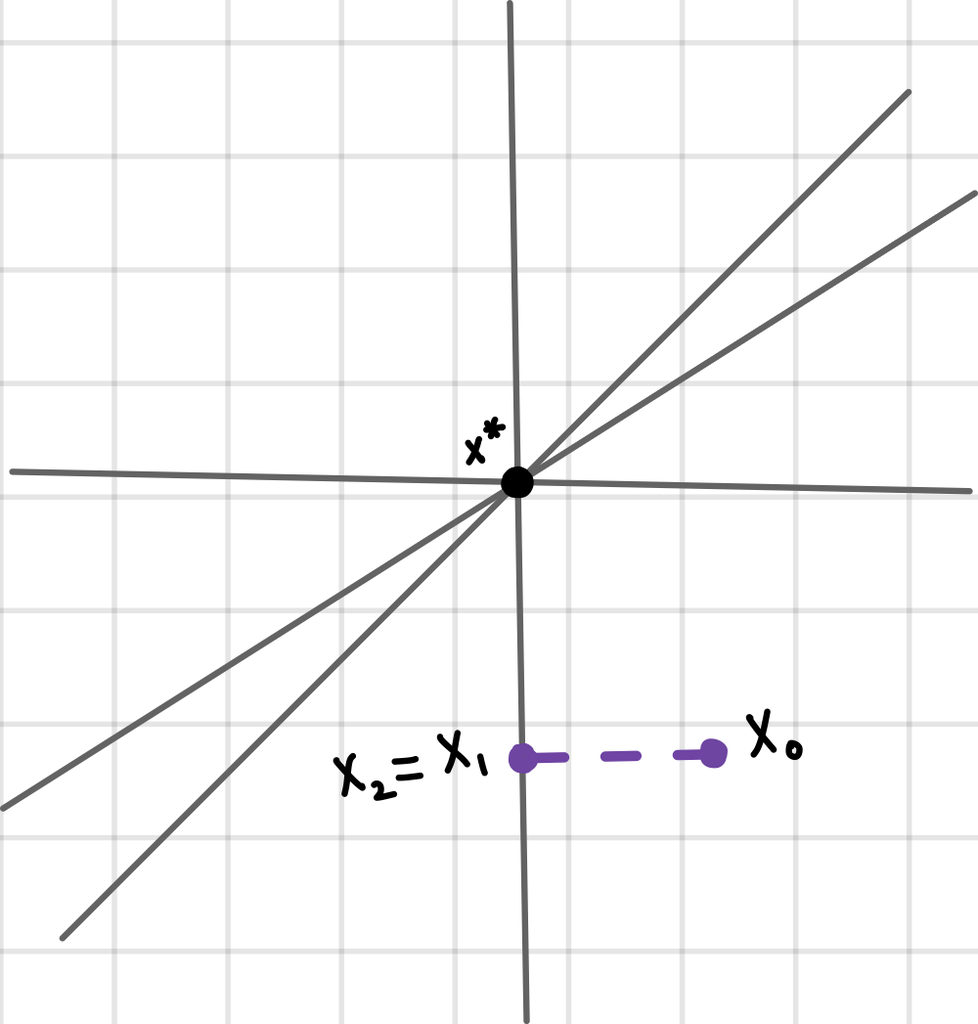

**Theorem: Collision probability**

$$P(I_1=I_2) = \sum_{i=1}^m p_i^2.$$

**Proof:**

Condition on $I_1$, applying the law of total probability with partitioning on the value of $I_1$:
$$P(I_1=I_2) = \sum_{i=1}^m P(I_2=i\mid I_1=i)\,P(I_1=i) = \sum_{i=1}^m P(I_2=i)\,p_i = \sum_{i=1}^m p_i\cdot p_i = \sum_{i=1}^m p_i^2,$$
using independence of $I_1,I_2$ for $P(I_2=i\mid I_1=i)=P(I_2=i)=p_i$. $\blacksquare$

**Why we care:** if row $i$ is sampled twice in a row, the second projection doesn’t update the iterate – the iterate already satisfies $a_i^\top x=b_i$ exactly after the first projection, so the second step makes *zero* progress toward $x^\star$. A high collision probability means wasted iterations.

**Fact**

The collision probability $\sum_i p_i^2$ is **minimized** by the *uniform* distribution $p_i=1/m$ (giving $\sum_i p_i^2=1/m$, the smallest possible value: $1=(\sum_i p_i)^2 \le m\sum_i p_i^2$ by Cauchy-Schwarz), and **maximized** at $1$ when all the probability mass sits on a single row. So concentrating the sampling distribution on a subset of rows comes at the cost of more wasted iterations.